# Binomial Distribution

Sreeda Vemuri

28 June, 2020

This assignment will introduce you to the binomial distribution. First, type your full name in the `author` field above.

Hint: the keyboard shortcut to create a code-block environment is `CTRL-ALT-I` (`CMD-ALT-I` on a Mac).

## Commenting

Inside the code blocks, the typed information after the pound key (#) are called *comments*. Programmers use comments to remind themselves and teammates what each section of code does.

Run the following chunk of code, try to start to understand how the numbers, variables, and syntax go together. Write (at least) 5 comments inside the code block to demonstrate your understanding.

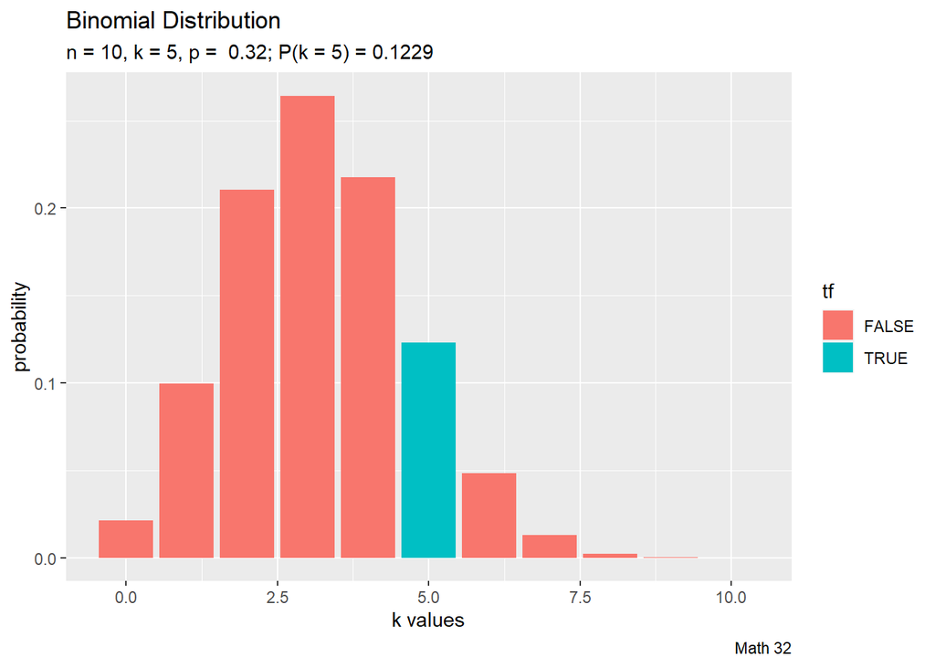

```r
# this is an example of a comment
n <- 10 # sample size
k <- 5 # median
p <- 0.32 # probability

kvals <- 0:n
tf <- kvals == k
probabilities <- dbinom(kvals, n, p)
df <- data.frame(kvals, tf, probabilities)

custom_subtitle <- paste0("n = ", n, ", ",
                          "k = ", k, ", ",
                          "p =  ", p, "; ",
                          "P(k = ", k,
                          ") = ", round(dbinom(k,n,p), 4)) # assigns letters for the variables, and also assigns a value to a function

ggplot(df, aes(x = kvals, y = probabilities, fill = tf)) + #creates a graph to plot the data above
  geom_bar(stat = "identity") +
  labs(title = "Binomial Distribution",
       subtitle = custom_subtitle,
       caption = "Math 32",
       x = "k values",
       y = "probability")
```